# How is Climate Change Affecting Farmers in McCall?

Claire Manning

10/14/2020

[figure not shown]

*This is a map of Idaho, the red dot pinpoints the town of McCall.*

## About McCall, Idaho…

McCall is a small mountain town in central Idaho, about a two hour drive from the capitol city of Boise. The town has a population of about 3,270 but the total number of people in the town fluctuates a lot during the tourist seasons. McCall is located in the most northern part of the Valley County; the rest of Valley County is mostly privately owned farmland. The biggest draw for McCall by far, is the pristine nature and mountains that surround the town. The town is surrounded by public lands, owned by the Bureau of Land Management, and beyond that, the Payette National Forest. This land is easily accessible to residents and tourists for a variety of outdoor recreation purposes.

My family has a small cabin in the town and we spend most weekends there. During the winter we spend alot of time skiing and snowshoing, and in the spring we hike and forage for mushrooms. In the summer we backpack to the nearby alpine lakes, swim in the rivers, and pick huckeberries in the forest. Outdoor recreation is arguably the most popular attraction in the town and the BLM and Forest Service lands are used heavily as a result. Despite this heavy land use, most residents and tourists tread lightly and are very careful to not disturb the nature. This attitude towards the natrual environment helps maintain the pristine quality of the surrounding nature and ecosystems, and allows for continued outdoor recreation.

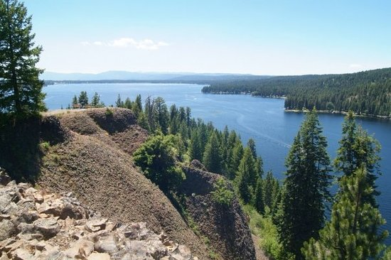

*This is a photo of Payette Lake in McCall. This photo is taken from the peninsula in Ponderosa State Park.*

## What are the political demographics in the area?

Politically, the state of Idaho is very conservative. Although McCall is less so, it is still leaning conservative. Democrats and Republicans remain at ideological odds over the causes of climate change and the effectiveness of policies to address it. While generally supportive of prioritizing alternative energy sources, Republicans differ by ideology, generation, and gender, in their views toward the environment (Pew Research, 2019). The most noticable rejection of human caused climate change occurs among conservative Republicans, which is one of the prominent ideologies present in the state. These political demographics result in less political attention or care given to climate initiatives in the state.

[figure not shown]

*This graphic shows the response from U.S. adults regarding the extent to which human acitivity and patterns in Earth’s environment contribute to global climate change. Image source: Pew Research Center.*

## How is climate change affecting McCall in general?

Climate change is affecting McCall in many ways, some of which are more noticable than others. Some of these changes are happening seasonally or over the short term, and some are happening over the long term. Many aspects of climate change are noticed by residents, specifically the rising temperatures and increases in wildfires, which are causing numerous ecological and economic implications in the area.

Some of the ecological changes that are occurring from rising temperatures include increased wildfires, destruction and disruption to wildlife habitats, and long term physical changes to the landscape. Certain invasive or destructive species take advantage of these changes in climate. One example of this can be seen in pine beetles. Rising temperatures have extended the season that pine beetles can survive, and caused an increase in the scope of pine beetle damage. Pine beetle infestations result in huge areas of dead forests that are much more prone to fires, which disrupts the habitats of many other species. Furthurmore, this causes economic implications because infested forests are much less attractive for outdoor recreation activities such as hiking, backpacking and mountain biking. Other ecological implications that are resulting from rising temperatures include earlier snowmelt (Kunkel *et al.*, 2009), and increases in the speed of streamflow (Tang *et al.*, 2012). These patterns result in changes in resource availability and disruptions to water management. The degradation and changes in the local environment are also causing disruptions to the local tourist economy, which is very important to the local economy as a whole. Rising temperatures have caused the main tourist seasons to shorten, most notably the winter sports season.

## What do these rises in temperature look like?

To help visualize this increase in temperature, I analyzed data collected from a weather station in McCall, Idaho and created a few graphs showing these temperature changes over time. This particular station is at an elevation of 1500 m and the data goes back to March, 1906. The data includes daily minimum and maximum temperatures at the station location on each given date. The station has used various typed of equipment over the years, and as of 2011 they have been using Nimbus.

I made graphs to depict the changes in daily maximum and daily minimum temperatures by month over the data period by changing the data from daily highs and lows to monthly means. The graphs of minimum temperature show the most notable changes over time, especially during late winter and spring. Because of this, I have chosen to include the graphs showing the tmin increases in temperature from January to June. For the analysis of this data, the null hypothesis was that there is no change in temperature over time. The data satisfies the standard assumptions of the analysis, with few missing data points. All of the missing datapoints occur during WWI. Based on the results of this analysis (p<.05), we can reject the null hypothesis and conclude that there is a significant upward trending change in temperature over time. The graphs below show these changes:

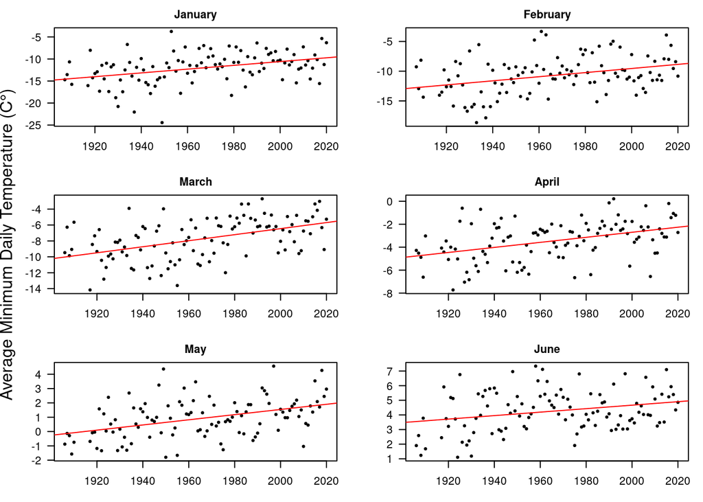

*Figure 1: These graphs show the upward trending change in minimum temperature over time. There is some missing data during WWI.*

## What is climate activism?

Unfortunately, most areas in Idaho are lacking climate activism. Climate activism occurs in political, group, and individual levels, and all levels are neccesary to effectively work toward acheiving climate sustainability. Govornment policies can help support climate activism, and people can form groups to lobby in support of sustainability initiatives, but ultimately, I beleive climate activism on an individual level is important and effective. Climate activism on an individual level is basically someone who is actively concerned about the changing climate and who is taking measures and making changes in their life to reduce their carbon footprint and adapt to the changing climate. These changes mostly occur on a personal level, and can include implementing energy saving techniques, being more concious about what we consume, and taking care to interact with our environment in ways that dont disturb the ecosystem. There are endless ways to do this, like turning off unused lights, purchasing more environmentally friendly brands, investing in reknewable energy, and reducing overal consumption of products.

For individuals in McCall who are looking for ways to become more involved in climate activism as an individual there are many resources available, but one specific report that I would like to highlight. This year, Anna Lindquist, a graduate student doing research at the University of Idaho’s McCall Outdoor Science School, produced a report for the City of McCall with grant funding from the Blue Cross of Idaho Foundation. This report is tittled: “McCall’s Framework for Climate Action Planning”. In creating this report, Lindquist explores the actions that other small mountain towns have taken to mitigate local impacts of climate change. Lindquist’s report highlights the reality of anthropogenic climate change, and creates a framework for climate action planning. This plan outlines specific steps that both the city of McCall and residents should take to address climate change.

## Literature Cited

Funk, C., & Hefferon, M. (2019, November). U.S. Public Views on Climate and Energy. Retrieved from https://www.pewresearch.org/science/2019/11/25/u-s-public-views-on-climate-and-energy/

Kunkel, M. L., Pierce, J. L. (2009). Reconstructing snowmelt in Idaho’s watershed using historic streamflow records. Climatic Change, 98(1-2), 155-176. doi:10.1007/s10584-009-9651-x

Lindquist, A. (2020). McCall’s Framework for Climate Action Planning (pp. 1-44, Rep.). McCall, Idaho: Anna Lindquist.

Running, K., Burke, J., Shipley, K. (2016). Perceptions of Environmental Change and Climate Concern Among Idaho’s Farmers. Society & Natural Resources, 30(6), 659-673. doi:10.1080/08941920.2016.1239151

Tang, C., Crosby, B. T., Wheaton, J. M., Piechota, T. C. (2012). Assessing streamflow sensitivity to temperature increases in the Salmon River Basin, Idaho. Global and Planetary Change, 88-89, 32-44. doi:10.1016/j.gloplacha.2012.03.002